# Model Selection & Model Performance

# 1. Existing Architecture

To get a general idea of how Convolutional Neural Networks operate and what their overall structure looks like I will create 3 classical networks LeNet-5, Alexnet & VGG-16. The purpose of this is to get a quick overview of how these networks preform. These are not the actual classical networks these are simply tests built with the same structure these networks once used.

## 1.1 LeNet-5

LeNet-5 is a rather small network. It has only convolutional layers along with 1 fully connected layer. The key difference between modern architecture and LeNet is that LeNet originally used tanh as it's activation function while modern network architectures use Relu as their activation function. The test below shows the differnce in using tanh with 3 convolutional layers.

### 1.1.1 Import the required libraries

```python
import tensorflow as tf
import numpy as np
import matplotlib
import matplotlib.pyplot as plt
from tensorflow.keras.models import Sequential
from tensorflow.keras.layers import Dense, Dropout, Activation, Flatten, Conv2D, MaxPooling2D, AveragePooling2D
from tensorflow.python.keras.optimizers import Adam, SGD, RMSprop, Adagrad
import pickle

%matplotlib inline
```

### 1.1.2 Import the data

```python
X = pickle.load(open("X.pickle","rb"))
y = pickle.load(open("y.pickle","rb"))
```

### 1.1.3 Set a random seed

```python
np.random.seed(1)
```

### 1.1.4 Normalize the data

```python
X = X/255.0
```

### 1.1.5 Create the Model

```python
model = Sequential()
```

### 1.1.6 Add the Convolution Layers

```python
model.add(Conv2D(16, (3,3), input_shape = X.shape[1:]))
model.add(Activation("tanh"))
model.add(AveragePooling2D(pool_size=(2,2)))

model.add(Conv2D(32, (3,3)))
model.add(Activation("tanh"))
model.add(AveragePooling2D(pool_size=(2,2)))

model.add(Conv2D(64, (3,3)))
model.add(Activation("tanh"))
model.add(AveragePooling2D(pool_size=(2,2)))
```

### 1.1.7 Adding the Dense Layers

```python
model.add(Flatten())
model.add(Dense(64))
model.add(Dropout(0.2))

model.add(Dense(1))
model.add(Activation("sigmoid"))
```

### 1.1.8 Compiling the Model

```python
model.compile(loss="binary_crossentropy",
             optimizer="Adam",
             metrics=['accuracy'])
```

### 1.1.9 Fit the Model

Mediocore results using this network the finall validation accuracy recorded was a mere 67% below in the models loss fails to converge.

```python
results = model.fit(X, y, batch_size=32, epochs=50, validation_split=0.2)
```

```
Train on 400 samples, validate on 100 samples
```

### 1.1.10 Plot the Models Loss

The plot below indicates that after 50 epochs the training loss did not converge but stayed on a steady path as the number of epochs increased. This example shows that small networks using the tanh activation function do not give good results. Later in this notebook you will see as I begin to use Relu the over loss of the network will converge.

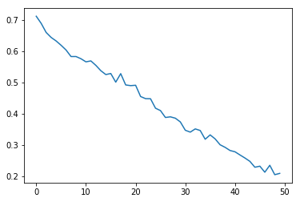

```python
plt.plot(results.history["loss"])
plt.show()
```

### 1.1.11 Futher visualizations

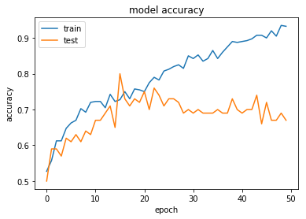

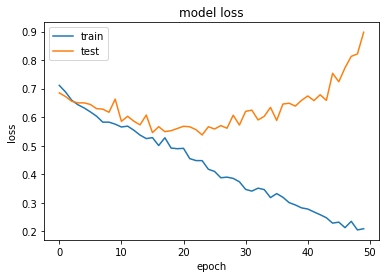

```python
plt.plot(results.history['acc'])
plt.plot(results.history['val_acc'])
plt.title('model accuracy')
plt.ylabel('accuracy')
plt.xlabel('epoch')
plt.legend(['train', 'test'], loc='upper left')
plt.show()

plt.plot(results.history['loss'])
plt.plot(results.history['val_loss'])
plt.title('model loss')
plt.ylabel('loss')
plt.xlabel('epoch')
plt.legend(['train', 'test'], loc='upper left')
plt.show()
```

## 1.2 AlexNet

### 1.2.1 Create the Model

```python
model = Sequential()
```

### 1.2.2 Add the Convolutional Layers

```python
model.add(Conv2D(64, (3,3), input_shape = X.shape[1:]))
model.add(Activation("relu"))
model.add(MaxPooling2D(pool_size=(2,2)))

model.add(Conv2D(64, (3,3)))
model.add(Activation("relu"))
model.add(MaxPooling2D(pool_size=(2,2)))

model.add(Conv2D(64, (3,3)))
model.add(Activation("relu"))

model.add(Conv2D(64, (3,3)))
model.add(Activation("relu"))

model.add(Conv2D(64, (3,3)))
model.add(Activation("relu"))
model.add(MaxPooling2D(pool_size=(2,2)))
```

### 1.2.3 Add the Dense Layers

```python
model.add(Flatten())
model.add(Dense(64))
model.add(Activation("relu"))

model.add(Dense(128))
model.add(Activation("relu"))

model.add(Dense(256))
model.add(Activation("relu"))

model.add(Dense(1))
model.add(Activation("sigmoid"))
```

### 1.2.4 Compile the Model

```python
model.compile(loss="binary_crossentropy",
             optimizer="Adam",
             metrics=['accuracy'])
```

### 1.2.5 Fit the Model

```python
results = model.fit(X, y, batch_size=32, epochs=50, validation_split=0.2)
```

```
Train on 400 samples, validate on 100 samples
```

### 1.2.6 Plot the Models Loss

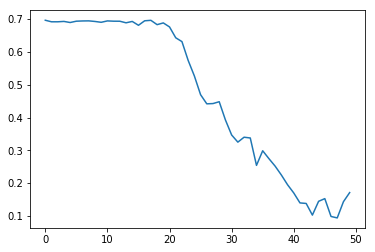

```python
plt.plot(results.history["loss"])
plt.show()
```

### 1.2.7 Futher visualizations

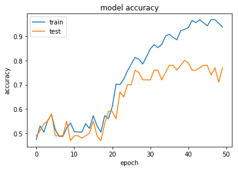

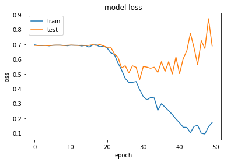

```python
plt.plot(results.history['acc'])
plt.plot(results.history['val_acc'])
plt.title('model accuracy')
plt.ylabel('accuracy')
plt.xlabel('epoch')
plt.legend(['train', 'test'], loc='upper left')
plt.show()

plt.plot(results.history['loss'])
plt.plot(results.history['val_loss'])
plt.title('model loss')
plt.ylabel('loss')
plt.xlabel('epoch')
plt.legend(['train', 'test'], loc='upper left')
plt.show()
```

## 1.3 VGG-16

Again to clarify this is not the VGG-16 model but a similar architecture, the purpose here is to get a general overview of how a large network architecture would preform on a set of small images. VGG-16 had more convolutional layers than what is being tested here but due to image size restrictions 9 is the max this network can use.

### 1.3.1 Create the Model

```python
model = Sequential()
```

### 1.3.2 Add the Convolutional Layers

```python
model.add(Conv2D(16, (3,3), input_shape = X.shape[1:]))
model.add(Activation("relu"))

model.add(Conv2D(16, (3,3)))
model.add(Activation("relu"))

model.add(Conv2D(16, (3,3)))
model.add(Activation("relu"))
model.add(MaxPooling2D(pool_size=(2,2)))

model.add(Conv2D(32, (3,3)))
model.add(Activation("relu"))

model.add(Conv2D(32, (3,3)))
model.add(Activation("relu"))

model.add(Conv2D(32, (3,3)))
model.add(Activation("relu"))
model.add(MaxPooling2D(pool_size=(2,2)))

model.add(Conv2D(64, (3,3)))
model.add(Activation("relu"))

model.add(Conv2D(64, (3,3)))
model.add(Activation("relu"))

model.add(Conv2D(64, (3,3)))
model.add(Activation("relu"))
model.add(MaxPooling2D(pool_size=(2,2)))
```

### 1.3.3 Add the Dense Layers

```python
model.add(Flatten())
model.add(Dense(512))
model.add(Activation("relu"))
model.add(Dropout(0.5))

model.add(Dense(256))
model.add(Activation("relu"))
model.add(Dropout(0.5))

model.add(Dense(128))
model.add(Activation("relu"))
model.add(Dropout(0.5))

model.add(Dense(1))
model.add(Activation("sigmoid"))
```

### 1.3.4 Compile the Model

```python
model.compile(loss="binary_crossentropy",
             optimizer="Adam",
             metrics=['accuracy'])
```

### 1.3.5 Fit the Model

```python
results = model.fit(X, y, batch_size=32, epochs=50, validation_split=0.2)
```

```
Train on 400 samples, validate on 100 samples
```

### 1.3.6 Plot the Models Loss

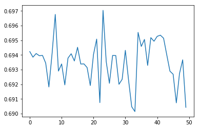

```python
plt.plot(results.history["loss"])
plt.show()
```

### 1.3.7 Futher visualisations

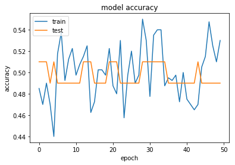

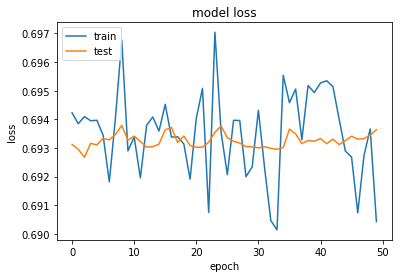

```python
plt.plot(results.history['acc'])
plt.plot(results.history['val_acc'])
plt.title('model accuracy')
plt.ylabel('accuracy')
plt.xlabel('epoch')
plt.legend(['train', 'test'], loc='upper left')
plt.show()

plt.plot(results.history['loss'])
plt.plot(results.history['val_loss'])
plt.title('model loss')
plt.ylabel('loss')
plt.xlabel('epoch')
plt.legend(['train', 'test'], loc='upper left')
plt.show()
```

# 2. Model Research

## 2.1 Model 1

This model is the first model which I will create and will consist of a very small architecture of both Convolutional and Dense Layers. The parameters will be randomly chosen and a range of these values will be extracted based on the overall results. Due to my understanding of the previous three architectures I now have a direct overview of what I should aim for in my final model. This model will use low parameters and gradually build up to higher values based on the results.

### 2.1.1 Create the model

```python
model = Sequential()
```

### 2.1.2 Add the Convolutional Layers

```python
model.add(Conv2D(256, (3,3), input_shape = X.shape[1:]))
model.add(Activation("relu"))
model.add(MaxPooling2D(pool_size=(2,2)))
```

### 2.1.3 Add the Dense Layers

```python
model.add(Flatten())
model.add(Dense(32))
model.add(Activation("relu"))

model.add(Dense(1))
model.add(Activation("sigmoid"))
```

### 2.1.4 Compile the Model

```python
model.compile(loss="binary_crossentropy",
             optimizer="Adam",
             metrics=['accuracy'])
```

### 2.1.5 Fit the Model

Results batch = 16 features = 16 dense = 32 val_acc = 76% val_loss = 0.9424  
Results batch = 16 features = 32 dense = 32 val_acc = 75% val_loss = 0.8764  
Results batch = 16 features = 64 dense = 32 val_acc = 76% val_loss = 0.8264  
Results batch = 16 features = 16 dense = 64 val_acc = 76% val_loss = 0.9473  
Results batch = 16 features = 32 dense = 64 val_acc = 79% val_loss = 0.7516  
Results batch = 16 features = 64 dense = 64 val_acc = 76% val_loss = 1.0026  
Results batch = 16 features = 16 dense = 32 val_acc = 76% val_loss = 0.7961  
Results batch = 32 features = 32 dense = 32 val_acc = 75% val_loss = 0.8951  
Results batch = 64 features = 64 dense = 32 val_acc = 77% val_loss = 0.7009  
Epoch 100 did not change the overall accuracy of the network. The tests shows that a constant accuracy of 70-80% was recorded when various parameters where changed using this 1 model. Futher tests increasing the convolutional layers could provide better results.  
Adding an extreme value of neurons on the dense layer was un-necessary and causes the models accuracy to reach 100% faster. It also does not benefit our model in any way as the val_acc does not increase past our recorded accuracy range of 70-80%. Furthermore this indicates that future use of extreme values for neurons is not needed and this range can be ruled out for grid searching.  
2 tests where undertaken using a stride=(1,1) & (2,2) with a padding of both "same" & "valid". Both parameters failed to improve the network further as results showed that the val_acc has decreased more since the use of both parameters. Results indicated an average val_acc of 72% when either paramater was used.

```python
results_05 = model.fit(X, y, batch_size=16, epochs=50, validation_split=0.33)
```

```
Train on 334 samples, validate on 166 samples
```

### 2.1.6 Plot the Models Loss

The model converges very fast in the epoch range of 5-10.

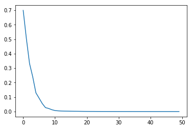

```python
plt.plot(results_05.history["loss"])
plt.show()
```

### 2.1.7 Further visualizations

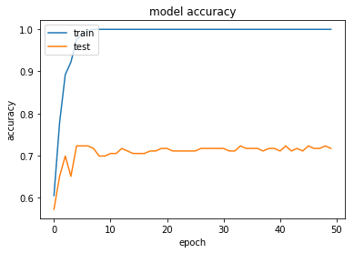

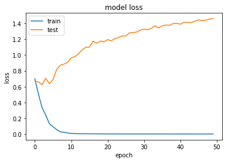

```python
plt.plot(results_05.history['acc'])
plt.plot(results_05.history['val_acc'])
plt.title('model accuracy')
plt.ylabel('accuracy')
plt.xlabel('epoch')
plt.legend(['train', 'test'], loc='upper left')
plt.show()

plt.plot(results_05.history['loss'])
plt.plot(results_05.history['val_loss'])
plt.title('model loss')
plt.ylabel('loss')
plt.xlabel('epoch')
plt.legend(['train', 'test'], loc='upper left')
plt.show()
```

### 2.1.8 Sub-plot the Results

Ass the Number of filters increase the Models loss seems to gradually get better over time taking less time to conevrege.

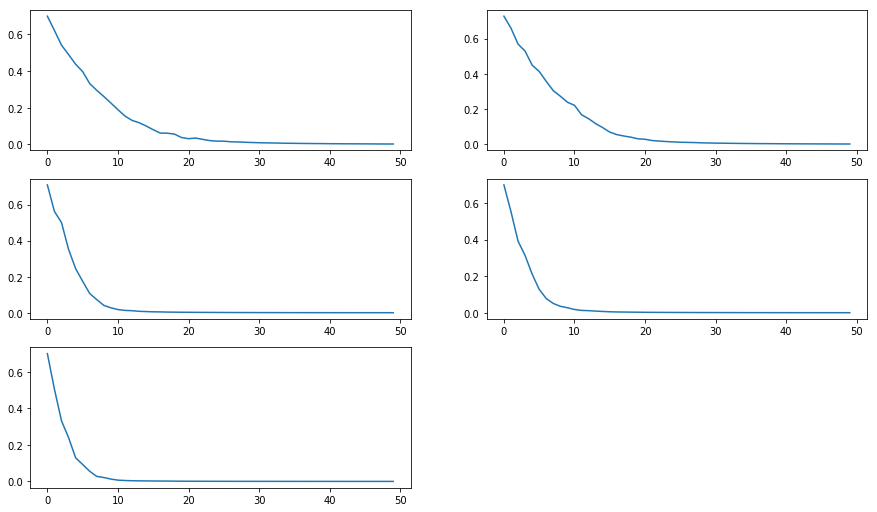

```python
fig = plt.figure(figsize=(15,15))

plt.subplot(5, 2, 1)
plt.plot(results_01.history['loss'])

plt.subplot(5, 2, 2)
plt.plot(results_02.history['loss'])

plt.subplot(5, 2, 3)
plt.plot(results_03.history['loss'])

plt.subplot(5, 2, 4)
plt.plot(results_04.history['loss'])

plt.subplot(5, 2, 5)
plt.plot(results_05.history['loss'])
```